# 2017-09-07-probability

#### 수식이 깨질 경우 새로고침을 눌러주세요.

## Probability for Data-Science ⑨

### 다변수 랜덤 변수

> $$ 하나의\; 샘플\;\omega에\; 대해\; 여러\; 개의\; 랜덤\;변수\; X,\; Y\; 등이\; 존재할\; 수\; 있다.$$

> ex) 사람 → 몸무게, 키, 성적, ...

> $$ 하나의\; 샘플\; \omega에\; 대해\; 다 \;수의\; 랜덤\; 변수\; X(\omega),\; Y(\omega),\;Z(\omega)를\; 정의할\; 수\; 있다.$$

> 다변수일 때, 가장 중요한 것은 이들 간의 **조건부 확률**이다.
> - 조건부 확률은 결합 확률로 정의되므로, **결합 확률**도 아주 중요하다.

$$ \bbox[7px, border:2px solid red]{P(A\;|\;B) = \frac{P(A,B)}{P(B)}} $$

### 다변수 랜덤 변수의 결합 분포(Joint Probability)

> 결합 누적 (확률) 분포 함수 Joint Cumulative (Probability) Distribution Function $$ \begin{eqnarray*} F(X=x, Y=y) &=& P( \{ ( -\infty \leq X < x ) \; \text{and} \; ( -\infty \leq Y < y ) \}) \\ &=& \int_{-\infty}^{x} \int_{-\infty}^{y} p(x, y)\;dxdy \end{eqnarray*} $$

> 결합 확률 밀도 함수(Joint Probability Density Function)로 확률값 계산 $$ \int_{x_1}^{x_2} \int_{y_1}^{y_2} p(x,y) dx dy = P( \{ (x_1 \leq X < x_2) \; \text{and} \; (y_1 \leq Y < y_2) \}) $$

### Marginal Probability

> Law of probability를 적용하면, marginal probability를 구할 수 있다. $$ p(x) \;=\; \sum_{i} p(x|y_{i})\cdot p(y_{i}) \;=\; \sum_{i} p(x, y_i)$$

∴ 다음이 성립한다.

$$ p(x) = \sum_{y_i} p(x,y_i) $$$$ p(y) = \sum_{x_i} p(x_i,y) $$$$ p(x) = \int_y p(x,y) dy $$$$ p(y) = \int_x p(x,y) dx $$

### Bayesian Rule

$$ p(x) = \sum_{y_i} p(x,y_i) = \sum_{y_i} p(x|y_i)p(y_i) $$$$ p(y) = \sum_{x_i} p(x_i,y) = \sum_{x_i} p(y|x_i)p(x_i) $$$$ p(x) = \int_y p(x,y) dy = \int_y p(x|y)p(y) dy $$$$ p(y) = \int_x p(x,y) dx = \int_x p(y|x)p(x) dx $$$$ p(x | y) = \frac{p(y | x)\, p(x)}{p(y)} $$

## 다변수 이산 확률 변수

> 카테고리 값을 가질 수 있는 이산확률변수가 두 개 이상 있는 경우
> 1. 각각의 확률변수에 대한 확률분포를 살펴본다.
> 2. 확률분포 쌍이 가지는 복합적인 확률분포도 반드시 살펴 봐야 한다.

> Ex) 1부터 6까지의 값을 가지는 카테고리 분포 확률변수 X와 Y를 생각해 보자.

$$ 확률\; 질량\; 함수(pmf)는\; 각각\; P_X(x),\; P_X(X=x)로\; 나타낼 \; 수\; 있다.$$$$ P_X(x=1)\; 또는\; P_X(1)은\; 확률변수\; X의\; 값이\; 1이\; 나올\; 확률이다.$$

### 결합 확률 질량 함수

$$ P_{XY}(x, y) $$$$(x, \;y)\; =\; (2,\; 3)일\; 때,\; 아래와\; 같이\; 표기한다.$$$$ P_{XY}(2, 3) \; 또는\; P_{XY}(x=2, y=3) $$

#### 다음은 6개의 카테고리 값 ( 0 ~ 5 ) 을 가지는 두 개의 이산확률변수의 확률 질량 함수의 예이다.

```python
# -*- coding: utf-8 -*-

import seaborn as sns
import pandas as pd
import scipy as sp
import matplotlib as mpl
import matplotlib.pylab as plt
import numpy as np
%matplotlib inline
sns.set()
sns.set_color_codes()
```

```python
data = np.array([[1, 2, 1, 0, 0, 0],
                 [0, 2, 3, 1, 0, 0],
                 [0, 4, 5, 4, 1, 0],
                 [0, 1, 4, 5, 4, 0],
                 [0, 0, 1, 3, 2, 0],
                 [0, 0, 0, 1, 2, 1]])
data
```

```
array([[1, 2, 1, 0, 0, 0],
       [0, 2, 3, 1, 0, 0],
       [0, 4, 5, 4, 1, 0],
       [0, 1, 4, 5, 4, 0],
       [0, 0, 1, 3, 2, 0],
       [0, 0, 0, 1, 2, 1]])
```

```python
pmf = np.round(data / data.sum(), decimals=4)
pmf
```

```
array([[ 0.0208,  0.0417,  0.0208,  0.    ,  0.    ,  0.    ],
       [ 0.    ,  0.0417,  0.0625,  0.0208,  0.    ,  0.    ],
       [ 0.    ,  0.0833,  0.1042,  0.0833,  0.0208,  0.    ],
       [ 0.    ,  0.0208,  0.0833,  0.1042,  0.0833,  0.    ],
       [ 0.    ,  0.    ,  0.0208,  0.0625,  0.0417,  0.    ],
       [ 0.    ,  0.    ,  0.    ,  0.0208,  0.0417,  0.0208]])
```

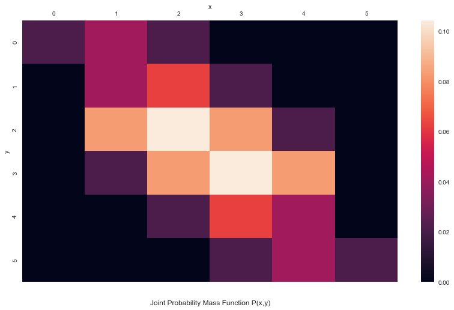

```python
plt.figure(figsize=(14,8))

# 히트맵을 그려라.
ax = sns.heatmap(pmf)

# x축 눈금을 위로 옮겨라.
ax.xaxis.tick_top()
# 'x'라는 축의 라벨을 위로 옮겨라.
ax.xaxis.set_label_position("top")

plt.xlabel("x")
plt.ylabel("y")

# y=-0.1은 타이틀의 위치 조정
plt.title("Joint Probability Mass Function P(x,y)", y=-0.1)
plt.show()
```

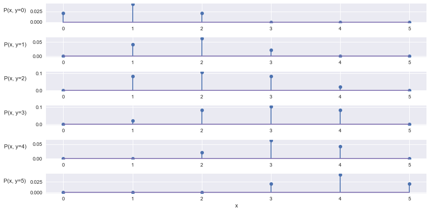

```python
plt.figure(figsize=(12,6))

# subplot을 그려라. / 줄기 그래프를 그리는데, 데이터는 pmf의 한 행씩 그려라. / Y축 레이블은 회전각 0도, labelpad 값으로 좌우 조정
plt.subplot(611); plt.stem(pmf[0, :]); plt.ylabel("P(x, y=0)", rotation=0, labelpad=30)
plt.subplot(612); plt.stem(pmf[1, :]); plt.ylabel("P(x, y=1)", rotation=0, labelpad=35)
plt.subplot(613); plt.stem(pmf[2, :]); plt.ylabel("P(x, y=2)", rotation=0, labelpad=40)
plt.subplot(614); plt.stem(pmf[3, :]); plt.ylabel("P(x, y=3)", rotation=0, labelpad=40)
plt.subplot(615); plt.stem(pmf[4, :]); plt.ylabel("P(x, y=4)", rotation=0, labelpad=35)
plt.subplot(616); plt.stem(pmf[5, :]); plt.ylabel("P(x, y=5)", rotation=0, labelpad=30)
plt.xlabel("x")
plt.tight_layout()
plt.show()
```

### 주변 확률질량함수 (marginal p.m.f)

> **주변 확률질량함수(marginal probability mass function)**
> - 두 확률변수 중 하나의 확률변수 값에 대해서만 확률분포를 표시한 함수
> - 즉, 다변수가 되기 이전의 단변수 확률질량함수

> 전 확률의 법칙(Law of probability)에 의해 다변수 확률질량함수를 통해 marginal pmf를 구할 수 있다.

$$ \begin{align}%\label{} \nonumber P_X(x) = \sum_{y_i} f_{XY}(x,y_i) \\ \nonumber P_Y(y) = \sum_{x_i} f_{XY}(x_i,y) \\ \end{align} $$

> 위의 든 예로 확률 질량 함수를 계산하면 다음과 같다.

```python
pmf_marginal_x = pmf.sum(axis=0)
pmf_marginal_x
```

```
array([ 0.0208,  0.1875,  0.2916,  0.2916,  0.1875,  0.0208])
```

```python
pmf_marginal_y = pmf.sum(axis=1)
pmf_marginal_y[:, np.newaxis]
```

```
array([[ 0.0833],
       [ 0.125 ],
       [ 0.2916],
       [ 0.2916],
       [ 0.125 ],
       [ 0.0833]])
```

### 조건부 확률질량함수 (conditional probability mass function)

> 다변량 확률 변수 중 **하나의 변수가 특정 값으로 고정되어 상수**가 되었을 때, 나머지 변수에 대한 pmf를 말한다.

$$ P_{X,Y \mid Y}(x,y \mid y) = P_{X \mid Y}(x \mid y) = \dfrac{P_{XY}(x, y)}{P_{Y}(y)} $$$$ P_{X,Y \mid Y}(x,y \mid y) = P_{Y \mid X}(y \mid x) = \dfrac{P_{XY}(x, y)}{P_{X}(x)} $$$$ 조건부\; pmf는\; 결합질량함수\; P_{XY}(x, y)에서\; y가\; 고정된\; 함수,\; 즉,\; 결합질량함수의\; 단면과\; 같아진다. $$$$ 다만,\; 조건부\; 확률질량함수의\; 합은 \;1이 \;된다. $$

> 위의 든 예로 조건부 확률 질량 함수를 계산하면 다음과 같다.

```python
pmf
```

```
array([[ 0.0208,  0.0417,  0.0208,  0.    ,  0.    ,  0.    ],
       [ 0.    ,  0.0417,  0.0625,  0.0208,  0.    ,  0.    ],
       [ 0.    ,  0.0833,  0.1042,  0.0833,  0.0208,  0.    ],
       [ 0.    ,  0.0208,  0.0833,  0.1042,  0.0833,  0.    ],
       [ 0.    ,  0.    ,  0.0208,  0.0625,  0.0417,  0.    ],
       [ 0.    ,  0.    ,  0.    ,  0.0208,  0.0417,  0.0208]])
```

#### 먼저 y = 0이라고 조건(고정)이 주어졌을 때, 조건부 확률을 계산하자.

$$ P_{X | Y} (x \;|\; y = 0) $$

```python
# y = 0 으로 고정 되었을 때의 x의 확률 값
pmf[0, :]
```

```
array([ 0.0208,  0.0417,  0.0208,  0.    ,  0.    ,  0.    ])
```

$$ ↑ \;\;\;\; P_{X,Y}(x,y=0) $$

```python
np.sum(pmf[0, :])
```

```
0.083299999999999999
```

$$ P_{Y} (y = 0) \;\; 값으로 \; 나누어 \;주지 \;않았기 \;때문에 \;확률의 \;합이 \;1이 \;아니다. $$

```python
cond_y0 = pmf[0, :]/pmf_marginal_y[0]
cond_y0
```

```
array([ 0.24969988,  0.50060024,  0.24969988,  0.        ,  0.        ,  0.        ])
```

```python
np.sum(cond_y0)
```

```
1.0
```

$$ \dfrac{P_{XY}(x, y = 0)}{P_{Y}(y = 0)}로 \;\; 계산하면\; 확률의\; 합\; = \;1인\; 것을\; 확인할\; 수\; 있다. $$

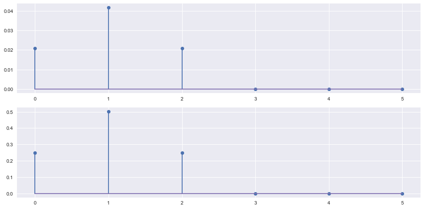

```python
plt.figure(figsize=(12,6))
plt.subplot(211); plt.stem(pmf[0, :])
plt.subplot(212); plt.stem(cond_y0)
plt.tight_layout()
plt.show()
```

#### 줄기 플랏을 그려보면 pmf_marginal_y[0]로 스케일링한 경우 확률의 합이 1이 되는 것을 확인할 수 있다.

#### 이제 y = 1이라고 조건(고정)이 주어졌을 때, 조건부 확률을 계산하자.

$$ P_{X | Y} (x \;|\; y = 1) $$

```python
pmf
```

```
array([[ 0.0208,  0.0417,  0.0208,  0.    ,  0.    ,  0.    ],
       [ 0.    ,  0.0417,  0.0625,  0.0208,  0.    ,  0.    ],
       [ 0.    ,  0.0833,  0.1042,  0.0833,  0.0208,  0.    ],
       [ 0.    ,  0.0208,  0.0833,  0.1042,  0.0833,  0.    ],
       [ 0.    ,  0.    ,  0.0208,  0.0625,  0.0417,  0.    ],
       [ 0.    ,  0.    ,  0.    ,  0.0208,  0.0417,  0.0208]])
```

```python
pmf[1, :]
```

```
array([ 0.    ,  0.0417,  0.0625,  0.0208,  0.    ,  0.    ])
```

$$ ↑ \;\;\;\; P_{X,Y}(x, y = 1) $$

```python
np.sum(pmf[1, :])
```

```
0.125
```

#### 역시 확률의 합이 1이 아니다. pmf_marginal_y[1]로 스케일링을 해주어야 한다.

```python
cond_y1 = pmf[1, :]/pmf_marginal_y[1]
cond_y1
```

```
array([ 0.    ,  0.3336,  0.5   ,  0.1664,  0.    ,  0.    ])
```

```python
np.sum(cond_y1)
```

```
1.0
```

$$ \dfrac{P_{XY}(x, y = 1)}{P_{Y}(y = 1)}로 \;\; 계산하면\; 확률의\; 합\; = \;1인\; 것을\; 확인할\; 수\; 있다. $$

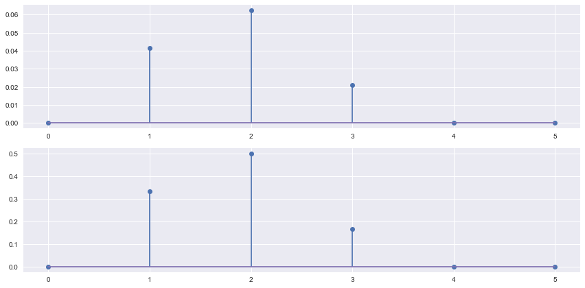

```python
plt.figure(figsize=(12,6))
plt.subplot(211); plt.stem(pmf[1, :])
plt.subplot(212); plt.stem(cond_y1)
plt.tight_layout()
plt.show()
```

## 다변수 연속 확률 변수

> 다변수 연속확률변수도 단변수 연속확률변수처럼 **누적확률분포함수를 먼저 정의한 후 이를 미분**하여 확률밀도함수를 정의하는 방법을 사용한다.

### 결합 누적확률분포함수

> $$ 두\; 확률\; 변수\; X,\; Y에\; 대한\; 결합\; 누적확률분포함수\; F_{XY}(x,\; y)는\; 다음과\; 같이\; 정의한다. $$

$$ \bbox[7px, border:2px solid red]{\begin{eqnarray*} F_{XY}(x, y) &=& P(\{ X < x \} \cap \{ Y < y \}) \\ \\&=& P(X < x,\; Y < y) \end{eqnarray*}} $$

$$ 만약\; 두\; 독립\; 변수\; x,\;\; y\; 중 \;구간의\; 끝 \;= \infty일\; 경우 \\ 해당\; 변수의\; 값은\; 어떤\; 값을\; 가져도\; 상관 \;없으므로\; 남은\; 하나의\; 변수에 \;대한\; 누적확률분포함수로\; 줄어든다.$$

이를 **주변 누적확률분포(marginal cumulative probability distribution)**이라고 한다.

$$ F_X(x)=F_{XY}(x, \infty) $$

$$ F_Y(x)=F_{XY}(\infty, y) $$

#### 결합 누적확률분포함수 F(x, y)는 다음과 같은 특성을 가진다.

$$ F_{XY}(\infty, \infty)=1 $$

$$ F_{XY}(-\infty, y)=F_{XY}(x,-\infty)=0 $$

> 두 변수 중 하나의 변수라도 -∞로 가면 그 누적확률 값은 0 이다.

### 결합 확률밀도함수

> 단변수 확률변수의 경우처럼 결합 누적확률분포함수를 미분하여 결합 확률밀도함수를 정의할 수 있다.

> 다만, 이 경우에는 독립 변수가 2개이므로 각각에 대해 모두 **편미분(partial differentication)**해야 한다.

$$ f_{XY} = \dfrac{\partial^2 F_{XY}(x, y)}{\partial x \partial y} $$

> 결합 확률 밀도 함수를 특정 구간에 대해 적분하면 해당 구간에 대한 **확률**이 된다.

$$ \int_{x_1}^{x_2} \int_{y_1}^{y_2} f_{XY}(x,y)dxdy = P\big(\{ x_1 \leq X \leq x_2, \; y_1 \leq Y \leq y_2 \}\big) $$

> 따라서 결합 확률 밀도 함수를 모든 변수에 대해 -∞에서 ∞ 까지 적분하면 값이 1이 된다.

$$ \int_{-\infty}^{\infty} \int_{-\infty}^{\infty} f_{XY}(x,y)dxdy=1 $$

> **Ex)**

> 다변수 정규 분포의 결합 확률 밀도의 예를 그려보자.

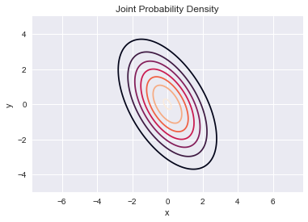

```python
# 다변량 가우시안 정규 분포 파라미터를 설정
mu = [0, 0]
cov = [[2, -1.4], [-1.4, 3.5]]
rv = sp.stats.multivariate_normal(mu, cov)

# x, y는 (-5, 5)구간에서 200개 점을 찍어라.
xx = np.linspace(-5, 5, 200)
yy = np.linspace(-5, 5, 200)

# x와 y를 좌표화

## xx, yy 같은 shape의 벡터 → XX, YY 서로 같은 매트릭스로 변환
XX, YY = np.meshgrid(xx, yy)

## np.dstack([XX, YY]) → XX.shape = YY.shape = (200, 200) | np.dstack([XX, YY]).shape = (200, 200, 2)
## XX와 YY의 각 엘리먼트만 묶어서 3차 행렬로 변경시켜준다. 엘리먼트가 (x,y)로 변경되어 2변량 변수를 한번에 input할 수 있다.
ZZ = rv.pdf(np.dstack([XX, YY]))

# 등고선을 그려라.
plt.contour(XX, YY, ZZ)

plt.xlabel("x")
plt.ylabel("y")
plt.title("Joint Probability Density")

# 세 개의 축 간격은 동일하게
plt.axis("equal")
plt.show()
```

```python
np.dstack([XX, YY]
```

#### 위 메소드는 아래와 같이 매트릭스를 변형해준다.

$$ \begin{bmatrix} x_{1,1} & x_{1,2} & \cdots & x_{1,200} \\ x_{2,1} & x_{2,2} & \cdots & x_{2,200} \\ \vdots & \vdots & \vdots & \vdots \\ x_{200,1} & x_{200,2} & \cdots & x_{200,200} \end{bmatrix} ,\;\;\;\; \begin{bmatrix} y_{1,1} & y_{1,2} & \cdots & y_{1,200} \\ y_{2,1} & y_{2,2} & \cdots & y_{2,200} \\ \vdots & \vdots & \vdots & \vdots \\ y_{200,1} & y_{200,2} & \cdots & y_{200,200} \end{bmatrix} \;\;\; \rightarrow \;\;\; \begin{bmatrix} (x_{1,1},\;y_{1,1}) & (x_{1,2},\;y_{1,2}) & \cdots & (x_{1,200},\;y_{1,200}) \\ (x_{2,1},\;y_{2,1}) & (x_{2,2},\;y_{2,2}) & \cdots & (x_{2,200},\;y_{2,200}) \\ \vdots & \vdots & \vdots & \vdots \\ (x_{200,1},\;y_{200,1}) & (x_{200,2},\;y_{200,2}) & \cdots & (x_{200,200},\;y_{200,200}) \end{bmatrix} $$

### 동일한 결합 확률 밀도 함수를 3차원으로 그리면 아래와 같다.

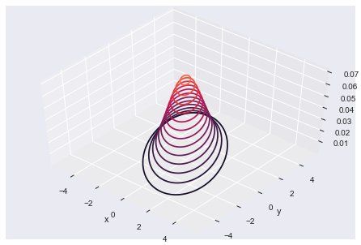

```python
from mpl_toolkits.mplot3d import Axes3D
fig = plt.figure()
ax = Axes3D(fig)
ax.contour(XX, YY, ZZ, levels=np.linspace(0, 0.1, 20))
ax.set_xlabel("x")
ax.set_ylabel("y")
ax.view_init(50, -50)
plt.show()
```

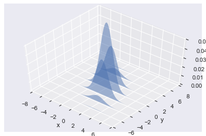

```python
from matplotlib.collections import PolyCollection
from matplotlib import colors as mcolors

xx = np.linspace(-8, 8, 100)
yy = np.linspace(-8, 8, 9)
XX, YY = np.meshgrid(xx, yy)
ZZ = rv.pdf(np.dstack([XX, YY]))

fig = plt.figure()
ax = fig.gca(projection='3d')

## x축으로 정사영
xs = np.hstack([0, xx, 0])

## xs와 똑같은 shpae의 0 행렬 만들기(input 차원의 0 행렬 출력)
zs = np.zeros_like(xs)

verts = []
for i, y in enumerate(yy):
    # xs와 똑같은 자리(처음과 마지막)의 원소는 0으로 두고, 나머지 값을 ZZ값으로 변경
    zs[1:-1] = ZZ[i]
    # xx, zs의 각 원소를 zip으로 묶어서 (x, y)가 한 엘리먼트가 되는 리스트 만듬.
    verts.append(list(zip(xx, zs)))

poly = PolyCollection(verts)
poly.set_alpha(0.5)
ax.add_collection3d(poly, zs=yy, zdir='y')

ax.set_xlabel('x')
ax.set_xlim3d(-8, 8)
ax.set_ylabel('y')
ax.set_ylim3d(-8, 8)
ax.set_zlabel('z')
ax.set_zlim3d(0, 0.05)
ax.view_init(50, -50)
plt.show()
```

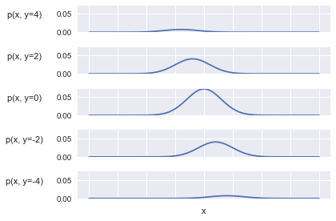

```python
# (range(6, 1, -1) → 6부터 2까지의 정수
for i, j in enumerate(range(6, 1, -1)):
    ax = plt.subplot(5, 1, i + 1)
    plt.plot(xx, ZZ[j, :])
    plt.ylim(0, 0.072)
    # x축 격자 없앨 것
    ax.xaxis.set_ticklabels([])

    # y는 한자리로 표현하고, 소수 첫째자리 숫자만 표현해라.
    plt.ylabel("p(x, y={:.0f})".format(yy[j]), rotation=0, labelpad=40)
plt.xlabel("x")
plt.tight_layout()
plt.show()
```

### 참고

```python
# 소수점 포함 15자리수로 표현하고, 소수점 둘째자리까지 출력해라!
'{:015.2f}'.format(3.141592653589793)
```

```
'000000000003.14'
```

### 주변 확률밀도함수

> **주변 확률밀도함수(marginal probability density function)**는 결합 확률밀도함수를 특정한 하나의 변수에 대해 가중평균한 값이다.

> 따라서 결합 확률밀도함수를 하나의 확률 변수에 대해서만 적분하여 구한다.
> - 가중평균(적분)으로 인해 차원이 한 개 줄어들기 때문에 2차원 확률 변수의 주변 확률 밀도 함수는 1차원 함수가 된다.

$$ \begin{align}%\label{} \nonumber f_X(x) = \int_{-\infty}^{\infty} f_{XY}(x,y)dy \\ \\ \nonumber f_Y(y) = \int_{-\infty}^{\infty} f_{XY}(x,y)dx \end{align} $$

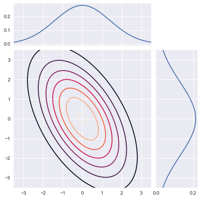

```python
from matplotlib.ticker import NullFormatter
from matplotlib import transforms
from scipy.integrate import simps # 심슨법칙(Simpson's rule)을 사용한 적분 계산

xx = np.linspace(-5, 5, 200)
yy = np.linspace(-5, 5, 100)
XX, YY = np.meshgrid(xx, yy)
ZZ = rv.pdf(np.dstack([XX, YY]))

# 심슨법칙(Simpson's rule)을 사용한 적분 계산
## x, y의 차원에 맞춰서 zz를 전치시켜 적분 계산
fx = [simps(Z, yy) for Z in ZZ.T]
fy = [simps(Z, xx) for Z in ZZ]

plt.figure(figsize=(6,6))

left, width = 0.1, 0.65
bottom, height = 0.1, 0.65
bottom_h = left_h = left + width + 0.02

rect1 = [left, bottom, width, height]
rect2 = [left, bottom_h, width, 0.2]
rect3 = [left_h, bottom, 0.2, height]

ax1 = plt.axes(rect1)
ax2 = plt.axes(rect2)
ax3 = plt.axes(rect3)

ax2.xaxis.set_major_formatter(NullFormatter())
ax3.yaxis.set_major_formatter(NullFormatter())

ax1.contour(XX, YY, ZZ)
ax2.plot(xx, fx)
base = ax3.transData
rot = transforms.Affine2D().rotate_deg(-90)
line = plt.plot(yy, fy, transform=rot + base)

ax1.set_xlim(-3.5, 3.5)
ax1.set_ylim(-3.5, 3.5)
ax2.set_xlim(-3.5, 3.5)
ax3.set_ylim(-3.5, 3.5)
plt.show()
```

### 조건부 확률밀도함수 (conditional probability density function)

> 다변수 확률 변수 중 하나의 값이 특정 값이라는 사실이 알려진 경우, 이러한 조건(가정)에 의해 변화한 나머지 확률변수에 대한 확률밀도함수를 말한다.

$$ f_{X \mid Y}(x \mid y_0) = \dfrac{f_{XY}(x, y=y_0)}{f_{Y}(y_0)} $$$$ f_{Y \mid X}(y \mid x_0) = \dfrac{f_{XY}(x, y=y_0)}{f_{X}(x_0)} $$

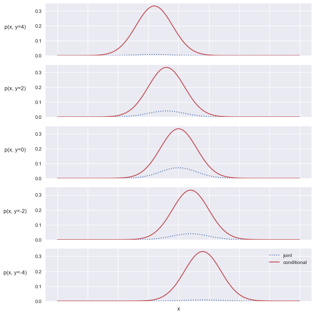

```python
from scipy.integrate import simps # 심슨법칙(Simpson's rule)을 사용한 적분 계산

xx = np.linspace(-8, 8, 100)
yy = np.linspace(-8, 8, 9)
XX, YY = np.meshgrid(xx, yy)
ZZ = rv.pdf(np.dstack([XX, YY]))

plt.figure(figsize=(9,9))

for i, j in enumerate(range(6, 1, -1)):
    ax = plt.subplot(5, 1, i + 1)
    plt.plot(xx, ZZ[j, :], 'b:', label="joint")
    marginal = simps(ZZ[j, :], xx)
    plt.plot(xx, ZZ[j, :] / marginal, 'r-', label="conditional")
    plt.ylim(0, 0.35)
    ax.xaxis.set_ticklabels([])
    plt.ylabel("p(x, y={:.0f})".format(yy[j]), rotation=0, labelpad=40)
plt.xlabel("x")
plt.tight_layout()
plt.legend()
plt.show()
```